# Birthrate by Country

Matthew Aird, Isabelle Stevens, Ryan Havel

## Introduction

Here’s A Link For More Fun Facts About Birthrates: https://www.childtrends.org/indicators/fertility-and-birth-rates

## Required Libraries

These libraries are needed to follow along with this tutorial.

```r
library(gapminder)
library(tidyverse)
library(tidyr)
library(readr)
library(broom)
library(randomForest)
library(rpart)
library("rpart.plot")
library(cvTools)
library(dplyr)
```

## 1. Gathering Data

The first step in the data science pipeline is data curation. This means acquiring all the data that we need to perform our analyses, and we can’t perform analysis without it. For this example, we are looking at the relationship between a country’s birthrate and factors such as GDP, income, and life expectancy for those countries. To do this, we need to pull Gapminder data from four sources:

1. A CSV file containing birthrate per country by year that can be downloaded from this link under the indicator “Babies per woman”: https://www.gapminder.org/data/
2. A CSV file containing data on income per person that can be downloaded from this link under the indicator “Income per person”: https://www.gapminder.org/data/
3. A CSV file containing data on child mortality per 1000 people that can be downloaded from this link under the indicator “Child mortality”: https://www.gapminder.org/data/
4. and a dataframe containing life expectancy per country by year from the gapminder library.

```r
children_per_woman_total_fertility <- read_csv("children_per_woman_total_fertility.csv")
children_per_woman_total_fertility
```

```
## # A tibble: 184 x 220
##    country `1800` `1801` `1802` `1803` `1804` `1805` `1806` `1807` `1808`
##    <chr>    <dbl>  <dbl>  <dbl>  <dbl>  <dbl>  <dbl>  <dbl>  <dbl>  <dbl>
##  1 Afghan~   7      7      7      7      7      7      7      7      7
##  2 Albania   4.6    4.6    4.6    4.6    4.6    4.6    4.6    4.6    4.6
##  3 Algeria   6.99   6.99   6.99   6.99   6.99   6.99   6.99   6.99   6.99
##  4 Angola    6.93   6.93   6.93   6.93   6.93   6.93   6.93   6.94   6.94
##  5 Antigu~   5      5      4.99   4.99   4.99   4.98   4.98   4.97   4.97
##  6 Argent~   6.8    6.8    6.8    6.8    6.8    6.8    6.8    6.8    6.8
##  7 Armenia   7.8    7.8    7.81   7.81   7.81   7.82   7.82   7.82   7.83
##  8 Austra~   6.5    6.48   6.46   6.44   6.42   6.4    6.38   6.36   6.34
##  9 Austria   5.1    5.1    5.1    5.1    5.1    5.1    5.1    5.1    5.1
## 10 Azerba~   8.1    8.1    8.1    8.1    8.1    8.1    8.1    8.1    8.1
## # ... with 174 more rows, and 210 more variables: `1809` <dbl>,
## #   `1810` <dbl>, `1811` <dbl>, `1812` <dbl>, `1813` <dbl>, `1814` <dbl>,
## #   `1815` <dbl>, `1816` <dbl>, `1817` <dbl>, `1818` <dbl>, `1819` <dbl>,
## #   `1820` <dbl>, `1821` <dbl>, `1822` <dbl>, `1823` <dbl>, `1824` <dbl>,
## #   `1825` <dbl>, `1826` <dbl>, `1827` <dbl>, `1828` <dbl>, `1829` <dbl>,
## #   `1830` <dbl>, `1831` <dbl>, `1832` <dbl>, `1833` <dbl>, `1834` <dbl>,
## #   `1835` <dbl>, `1836` <dbl>, `1837` <dbl>, `1838` <dbl>, `1839` <dbl>,
## #   `1840` <dbl>, `1841` <dbl>, `1842` <dbl>, `1843` <dbl>, `1844` <dbl>,
## #   `1845` <dbl>, `1846` <dbl>, `1847` <dbl>, `1848` <dbl>, `1849` <dbl>,
## #   `1850` <dbl>, `1851` <dbl>, `1852` <dbl>, `1853` <dbl>, `1854` <dbl>,
## #   `1855` <dbl>, `1856` <dbl>, `1857` <dbl>, `1858` <dbl>, `1859` <dbl>,
## #   `1860` <dbl>, `1861` <dbl>, `1862` <dbl>, `1863` <dbl>, `1864` <dbl>,
## #   `1865` <dbl>, `1866` <dbl>, `1867` <dbl>, `1868` <dbl>, `1869` <dbl>,
## #   `1870` <dbl>, `1871` <dbl>, `1872` <dbl>, `1873` <dbl>, `1874` <dbl>,
## #   `1875` <dbl>, `1876` <dbl>, `1877` <dbl>, `1878` <dbl>, `1879` <dbl>,
## #   `1880` <dbl>, `1881` <dbl>, `1882` <dbl>, `1883` <dbl>, `1884` <dbl>,
## #   `1885` <dbl>, `1886` <dbl>, `1887` <dbl>, `1888` <dbl>, `1889` <dbl>,
## #   `1890` <dbl>, `1891` <dbl>, `1892` <dbl>, `1893` <dbl>, `1894` <dbl>,
## #   `1895` <dbl>, `1896` <dbl>, `1897` <dbl>, `1898` <dbl>, `1899` <dbl>,
## #   `1900` <dbl>, `1901` <dbl>, `1902` <dbl>, `1903` <dbl>, `1904` <dbl>,
## #   `1905` <dbl>, `1906` <dbl>, `1907` <dbl>, `1908` <dbl>, ...
```

```r
income_per_person_gdppercapita_ppp_inflation_adjusted <- read_csv("income_per_person_gdppercapita_ppp_inflation_adjusted.csv")
income_per_person_gdppercapita_ppp_inflation_adjusted
```

```
## # A tibble: 193 x 242
##    country `1800` `1801` `1802` `1803` `1804` `1805` `1806` `1807` `1808`
##    <chr>    <dbl>  <dbl>  <dbl>  <dbl>  <dbl>  <dbl>  <dbl>  <dbl>  <dbl>
##  1 Afghan~    603    603    603    603    603    603    603    603    603
##  2 Albania    667    667    667    667    667    668    668    668    668
##  3 Algeria    715    716    717    718    719    720    721    722    723
##  4 Andorra   1200   1200   1200   1200   1210   1210   1210   1210   1220
##  5 Angola     618    620    623    626    628    631    634    637    640
##  6 Antigu~    757    757    757    757    757    757    757    758    758
##  7 Argent~   1510   1510   1510   1510   1510   1510   1510   1510   1510
##  8 Armenia    514    514    514    514    514    514    514    514    514
##  9 Austra~    814    816    818    820    822    824    825    827    829
## 10 Austria   1850   1850   1860   1870   1880   1880   1890   1900   1910
## # ... with 183 more rows, and 232 more variables: `1809` <dbl>,
## #   `1810` <dbl>, `1811` <dbl>, `1812` <dbl>, `1813` <dbl>, `1814` <dbl>,
## #   `1815` <dbl>, `1816` <dbl>, `1817` <dbl>, `1818` <dbl>, `1819` <dbl>,
## #   `1820` <dbl>, `1821` <dbl>, `1822` <dbl>, `1823` <dbl>, `1824` <dbl>,
## #   `1825` <dbl>, `1826` <dbl>, `1827` <dbl>, `1828` <dbl>, `1829` <dbl>,
## #   `1830` <dbl>, `1831` <dbl>, `1832` <dbl>, `1833` <dbl>, `1834` <dbl>,
## #   `1835` <dbl>, `1836` <dbl>, `1837` <dbl>, `1838` <dbl>, `1839` <dbl>,
## #   `1840` <dbl>, `1841` <dbl>, `1842` <dbl>, `1843` <dbl>, `1844` <dbl>,
## #   `1845` <dbl>, `1846` <dbl>, `1847` <dbl>, `1848` <dbl>, `1849` <dbl>,
## #   `1850` <dbl>, `1851` <dbl>, `1852` <dbl>, `1853` <dbl>, `1854` <dbl>,
## #   `1855` <dbl>, `1856` <dbl>, `1857` <dbl>, `1858` <dbl>, `1859` <dbl>,
## #   `1860` <dbl>, `1861` <dbl>, `1862` <dbl>, `1863` <dbl>, `1864` <dbl>,
## #   `1865` <dbl>, `1866` <dbl>, `1867` <dbl>, `1868` <dbl>, `1869` <dbl>,
## #   `1870` <dbl>, `1871` <dbl>, `1872` <dbl>, `1873` <dbl>, `1874` <dbl>,
## #   `1875` <dbl>, `1876` <dbl>, `1877` <dbl>, `1878` <dbl>, `1879` <dbl>,
## #   `1880` <dbl>, `1881` <dbl>, `1882` <dbl>, `1883` <dbl>, `1884` <dbl>,
## #   `1885` <dbl>, `1886` <dbl>, `1887` <dbl>, `1888` <dbl>, `1889` <dbl>,
## #   `1890` <dbl>, `1891` <dbl>, `1892` <dbl>, `1893` <dbl>, `1894` <dbl>,
## #   `1895` <dbl>, `1896` <dbl>, `1897` <dbl>, `1898` <dbl>, `1899` <dbl>,
## #   `1900` <dbl>, `1901` <dbl>, `1902` <dbl>, `1903` <dbl>, `1904` <dbl>,
## #   `1905` <dbl>, `1906` <dbl>, `1907` <dbl>, `1908` <dbl>, ...
```

```r
gapdata <- data.frame(gapminder)
head(gapdata)
```

```
##       country continent year lifeExp      pop gdpPercap
## 1 Afghanistan      Asia 1952  28.801  8425333  779.4453
## 2 Afghanistan      Asia 1957  30.332  9240934  820.8530
## 3 Afghanistan      Asia 1962  31.997 10267083  853.1007
## 4 Afghanistan      Asia 1967  34.020 11537966  836.1971
## 5 Afghanistan      Asia 1972  36.088 13079460  739.9811
## 6 Afghanistan      Asia 1977  38.438 14880372  786.1134
```

```r
child_mortality_0_5_year_olds_dying_per_1000_born <- read_csv("child_mortality_0_5_year_olds_dying_per_1000_born.csv")
head(child_mortality_0_5_year_olds_dying_per_1000_born)
```

```
## # A tibble: 6 x 220
##   country `1800` `1801` `1802` `1803` `1804` `1805` `1806` `1807` `1808`
##   <chr>    <dbl>  <dbl>  <dbl>  <dbl>  <dbl>  <dbl>  <dbl>  <dbl>  <dbl>
## 1 Afghan~    469    469    469    469    469    469    470    470    470
## 2 Albania    375    375    375    375    375    375    375    375    375
## 3 Algeria    460    460    460    460    460    460    460    460    460
## 4 Andorra     NA     NA     NA     NA     NA     NA     NA     NA     NA
## 5 Angola     486    486    486    486    486    486    486    486    486
## 6 Antigu~    474    470    466    462    458    455    451    447    444
## # ... with 210 more variables: `1809` <dbl>, `1810` <dbl>, `1811` <dbl>,
## #   `1812` <dbl>, `1813` <dbl>, `1814` <dbl>, `1815` <dbl>, `1816` <dbl>,
## #   `1817` <dbl>, `1818` <dbl>, `1819` <dbl>, `1820` <dbl>, `1821` <dbl>,
## #   `1822` <dbl>, `1823` <dbl>, `1824` <dbl>, `1825` <dbl>, `1826` <dbl>,
## #   `1827` <dbl>, `1828` <dbl>, `1829` <dbl>, `1830` <dbl>, `1831` <dbl>,
## #   `1832` <dbl>, `1833` <dbl>, `1834` <dbl>, `1835` <dbl>, `1836` <dbl>,
## #   `1837` <dbl>, `1838` <dbl>, `1839` <dbl>, `1840` <dbl>, `1841` <dbl>,
## #   `1842` <dbl>, `1843` <dbl>, `1844` <dbl>, `1845` <dbl>, `1846` <dbl>,
## #   `1847` <dbl>, `1848` <dbl>, `1849` <dbl>, `1850` <dbl>, `1851` <dbl>,
## #   `1852` <dbl>, `1853` <dbl>, `1854` <dbl>, `1855` <dbl>, `1856` <dbl>,
## #   `1857` <dbl>, `1858` <dbl>, `1859` <dbl>, `1860` <dbl>, `1861` <dbl>,
## #   `1862` <dbl>, `1863` <dbl>, `1864` <dbl>, `1865` <dbl>, `1866` <dbl>,
## #   `1867` <dbl>, `1868` <dbl>, `1869` <dbl>, `1870` <dbl>, `1871` <dbl>,
## #   `1872` <dbl>, `1873` <dbl>, `1874` <dbl>, `1875` <dbl>, `1876` <dbl>,
## #   `1877` <dbl>, `1878` <dbl>, `1879` <dbl>, `1880` <dbl>, `1881` <dbl>,
## #   `1882` <dbl>, `1883` <dbl>, `1884` <dbl>, `1885` <dbl>, `1886` <dbl>,
## #   `1887` <dbl>, `1888` <dbl>, `1889` <dbl>, `1890` <dbl>, `1891` <dbl>,
## #   `1892` <dbl>, `1893` <dbl>, `1894` <dbl>, `1895` <dbl>, `1896` <dbl>,
## #   `1897` <dbl>, `1898` <dbl>, `1899` <dbl>, `1900` <dbl>, `1901` <dbl>,
## #   `1902` <dbl>, `1903` <dbl>, `1904` <dbl>, `1905` <dbl>, `1906` <dbl>,
## #   `1907` <dbl>, `1908` <dbl>, ...
```

## 2. Tidying Data

Tidying data is a point in the pipeline where you must change aspects of the datasets to handle missing data and to fit the model of a rectangular data structure. This means that each attribute must form a column, each entity must form a row, and each type of entity must form a table. There are 4 main operations that need to be done to our data in order for our analysis to be accurate:

1. Fixing the country names
2. Fixing the columns
3. Transforming numbers
4. Joining datasets

First, there were several naming inconsistencies with countries where some data sets called Yemen “Yemen, Rep.” and others just said “Yemen” this had to be fixed so all data could be included into one data set.

```r
gapdata$country <- as.character(gapdata$country)
gapdata$country[gapdata$country == "Yemen, Rep."] <- "Yemen"
```

Secondly, the four data sets used in this analysis have differing column semantics regarding year values. As you can see from the extensive column list on the birthrate, child mortality, and income per person table, they include the value of each year as its own column. This is not tidy data because the year attribute does not form a single column. This also differs from the gapminder data package which has year as a singular column. We fix this discrepancy by using the gather function. This changes the first three data sets by making year into a singular column and converting the data into a numeric type.

```r
income_df <- income_per_person_gdppercapita_ppp_inflation_adjusted %>%
  gather(year, income_per_person, -country, convert = TRUE)
birthrate_df <- children_per_woman_total_fertility %>%
  gather(year, birthrate, -country, convert = TRUE)
mortality_df <- child_mortality_0_5_year_olds_dying_per_1000_born %>%
  gather(year, child_mort_per, -country, convert = TRUE)
```

Then, we need to make our child mortality dataset a percentage. We do this to simplify our data and make it more understandable. To do this, we divide each country by 10 because the original number given is child deaths per 1000 children.

```r
mortality_df$child_mort_per <- mortality_df$child_mort_per/10
```

Lastly, we need to join all four tables into a single dataframe to make analysis go more smoothly.

```r
birthrate_df <- birthrate_df %>%
  inner_join(gapdata, by = c("country", "year"))  %>%
  inner_join(income_df, by = c("country", "year")) %>%
  inner_join(mortality_df, by = c("country", "year"))
```

For more information on Data Tidying, Garrett Grolemund has an excellent article about it on his GitHub: https://garrettgman.github.io/tidying/

## 3. Exploratory Data Analysis

Now that our data has been tidied and formatted correctly, we can begin some of our analysis. Exploratory Data Analysis is a crucial part of the data science pipeline. Here we great visual aids to notice any trends or patterns with the data. This is where we will see if certain attributes affect overall birthrates.

### 3.1 Factors to consider

Here we look at several analyses that try to understand what factors lead to the increase or decrease in a country’s birthrate.

#### Birthrate vs. Continent

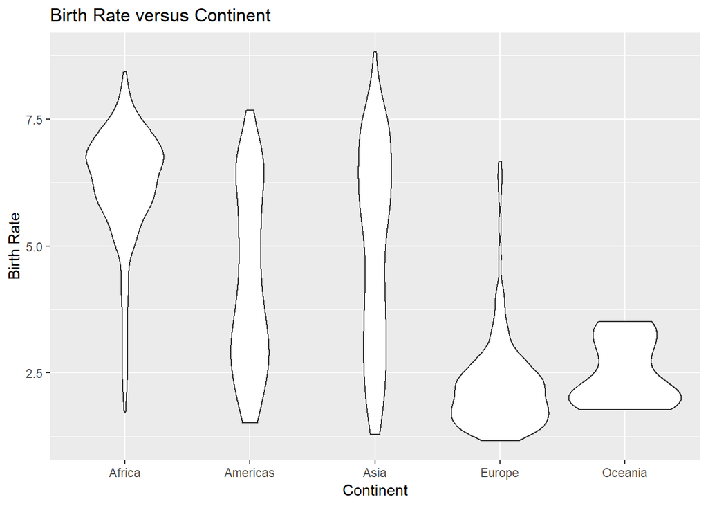

```r
birthrate_df %>%
  ggplot(aes(x=continent, y=birthrate)) +
  geom_violin() +
  labs(title="Birth Rate versus Continent", x="Continent", y="Birth Rate")
```

This violin graph above shows the spread of birthrate depending on the continent. As you can see countries like Europe and Oceania have a high frequency of low birthrates. While Africa has a high frequency for high birthrates. The Americas and Asia have a spread of almost equal frequency for both high and low birthrates. This chart shows that continent has an effect on birthrates with these large differences. This can be attributed to either differing regional government bodies or governments in the same region having the same amount of wealth or political system or even differing regional cultures. This would subsequently have an effect on access to contraceptive healthcare and education.

#### Average Birthrate vs. year

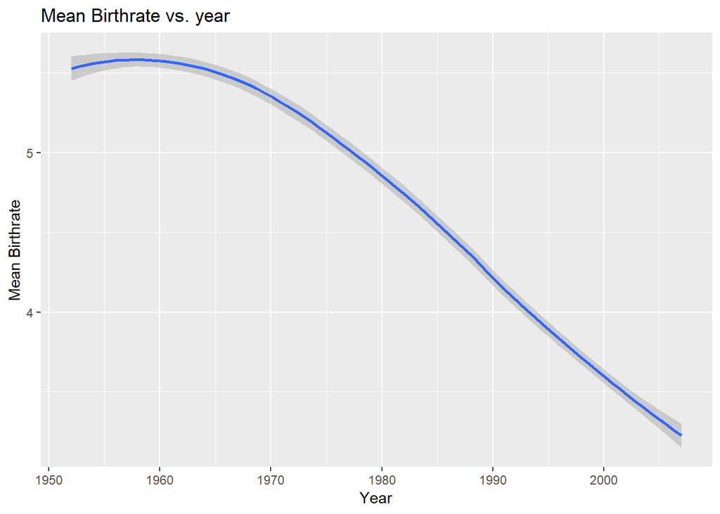

```r
plot_data <- group_by(birthrate_df, year) %>% summarize(mean_birth = mean(birthrate))
plot_data %>%
    ggplot(aes(x = year, y = mean_birth)) +
    geom_smooth() +
    labs(title = "Mean Birthrate vs. year", x = "Year", y = "Mean Birthrate")
```

This line plot above shows the downward trend of birthrates as years go by. This can be attributed to improvements in women’s education and rights along with the increased access to contraceptive methods around the world.

#### Birthrate vs. continent over time

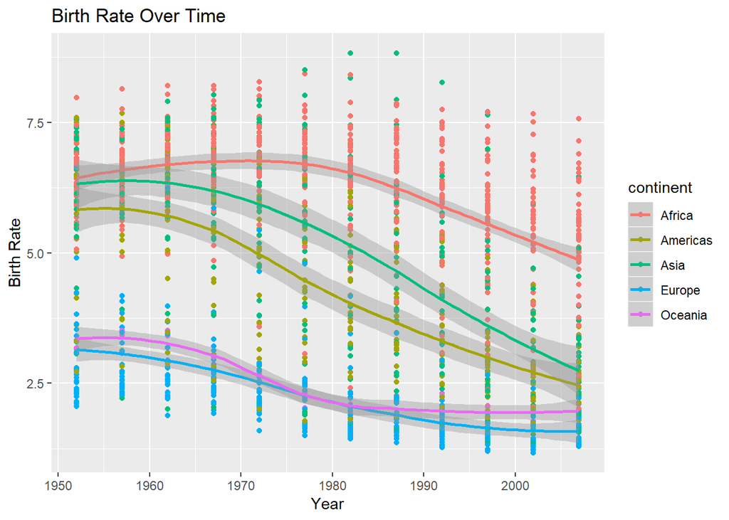

```r
birthrate_df %>%
  ggplot(aes(x= year, y=birthrate, color = continent)) +
  geom_point() +
  geom_smooth() +
  labs(title="Birth Rate Over Time", x="Year", y="Birth Rate")
```

The chart above shows the trend of birthrates over time depending on continent. As we can see both factors have an effect on birthrates. When we try to build a model to predict the birthrate of any given country, having one of these factors and not the other would result in less accurate model and would be less useful.

#### Birthrate vs. Income Per Person

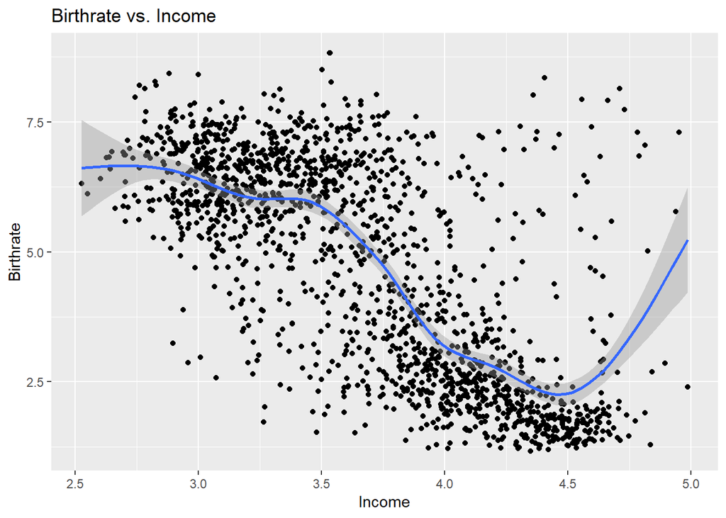

```r
birthrate_df %>%
    ggplot(aes(x = log10(income_per_person), y = birthrate)) +
    geom_point() + geom_smooth(lm=loess) +
    labs(title = "Birthrate vs. Income", x = "Income", y = "Birthrate")
```

In the graph above we see that as income per person increases, birthrate decreases. This could point to a theory that lower income countries have higher birthrates due to lack of education, no family planning resources and no widely available contraception methods. Income per person is a contributing factor to birthrate. There does exists several outliers in our data when income increases and these could be attributed to large wealth gaps in a country’s population which means poor people are not counted properly and only reflected in a high birthrate. Another explanation for these outliers could be there exists a strong culture of motherhood which keeps the birthrate high regardless of income.

#### Birthrate vs. Life Expectancy

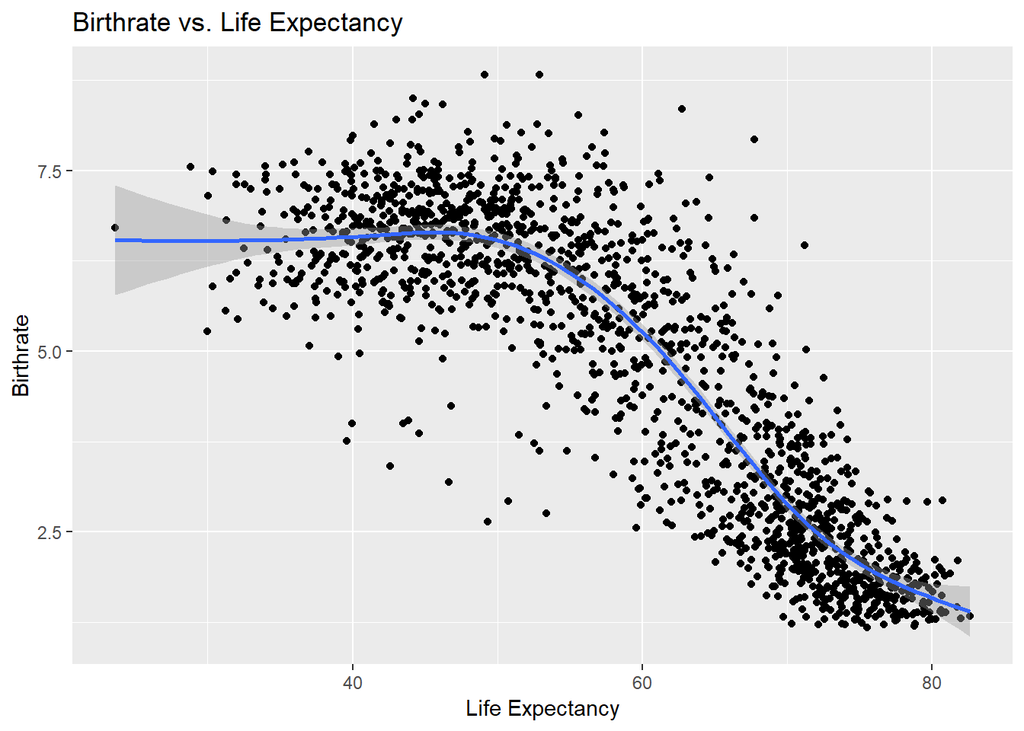

```r
birthrate_df %>%
    ggplot(aes(x = lifeExp, y = birthrate)) +
    geom_point() + geom_smooth(lm=loess) +
    labs(title = "Birthrate vs. Life Expectancy", x = "Life Expectancy", y = "Birthrate")
```

#### Birthrate vs. Child Mortality

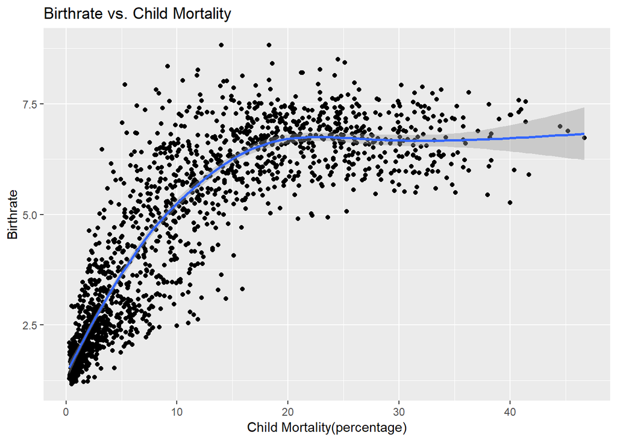

```r
birthrate_df %>%
    ggplot(aes(x = child_mort_per, y = birthrate)) +
    geom_point() + geom_smooth(lm = loess) +
    labs(title = "Birthrate vs. Child Mortality", x = "Child Mortality(percentage)", y = "Birthrate")
```

A final factor we wanted to analyze was a country’s child mortality rate and its effect on birthrate. As one can see from the chart above, as a country’s child mortality increases, so does the birthrate to an extent. At about the 20% mark, a country’s birthrate stabilizes. This could be due to how women tend physically not have more children or enough children have survived to stop trying to birth more children.

## 4. Machine Learning

### 4.1 Creating a Linear Regression Model

Linear Model:
$$Birth Rate = \beta_0 + \beta_1 * Continent + \beta_2 * Year + \beta_3 * IncomePerPerson + \beta_4 * Life Expectancy + \beta_5 * ChildMortality$$
We have taken the factors that we analyzed earlier to now create a model that can predict a country’s birthrate depending on it’s continent, what year it is, the Income of a person in that country, that country’s life expectancy that year, and the child mortality rate that year.

### 4.2 Hypothesis testing on model

```r
fit <- lm(birthrate ~ year + continent + income_per_person + lifeExp + child_mort_per, data = birthrate_df)
broom::tidy(fit) %>% knitr::kable()
```

| term | estimate | std.error | statistic | p.value |
| --- | --- | --- | --- | --- |
| (Intercept) | 40.7247306 | 3.6522706 | 11.150524 | 0.0000000 |
| year | -0.0155730 | 0.0018344 | -8.489560 | 0.0000000 |
| continentAmericas | -0.4006295 | 0.0880924 | -4.547832 | 0.0000058 |
| continentAsia | -0.2046664 | 0.0749287 | -2.731480 | 0.0063738 |
| continentEurope | -1.7381258 | 0.1028417 | -16.900974 | 0.0000000 |
| continentOceania | -1.2904269 | 0.2207723 | -5.845058 | 0.0000000 |
| income_per_person | 0.0000035 | 0.0000027 | 1.287953 | 0.1979474 |
| lifeExp | -0.0836002 | 0.0062811 | -13.309838 | 0.0000000 |
| child_mort_per | 0.0168585 | 0.0068289 | 2.468698 | 0.0136637 |

We then test the model we created to see if all the factors allow us to reject the null hypothesis. That means if we reject the null hypothesis that a certain factor does actually have an effect on a country’s birthrate. The way to determine this is through a factor’s p-value, if it is below 0.05 then it is statistically significant in a country’s birthrate. If it is above 0.05 then we can not be certain if a factor actually has an effect on a country’s birthrate.

As you can see from the table above, only the income per person variable has a p-value above 0.05 which means we can not be certain if our income variable has an effect on a country’s birthrate. While all the other variables have a p-value below 0.05 which means we can reject the null hypothesis for those variables.

You may notice that Africa is missing in our model analysis, that is because the continent variable is categorical and thus the rest of the possible continents in our model analysis are just the amount a country’s birthrate would change if it were on that continent versus Africa.

### 4.3 plotting correctness of model

Fitted vs. Residuals

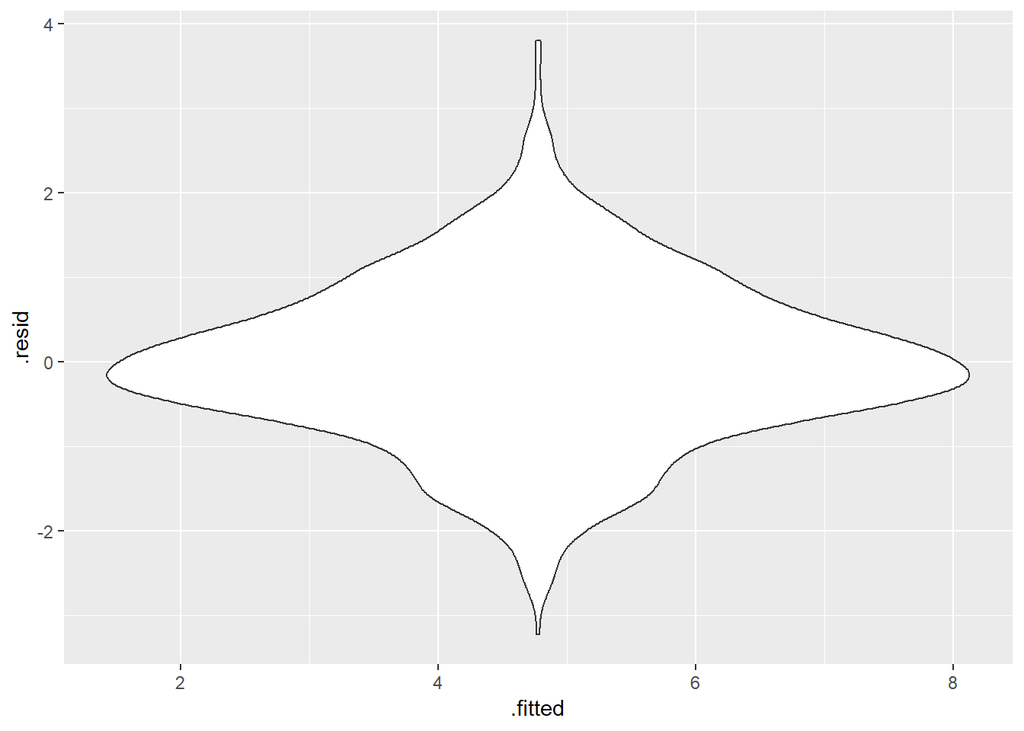

```r
augmentedData <- fit %>% augment() %>% select(-.se.fit, -.hat, -.sigma, -.cooksd, -.std.resid)
augmentedData %>% ggplot(aes(x = .fitted, y = .resid)) + geom_violin()
```

This graph shows us that our model is mostly correct with a high frequency at or around zero. This means we predicted (or almost correctly) the correct birthrates for countries.

Year vs. Residuals

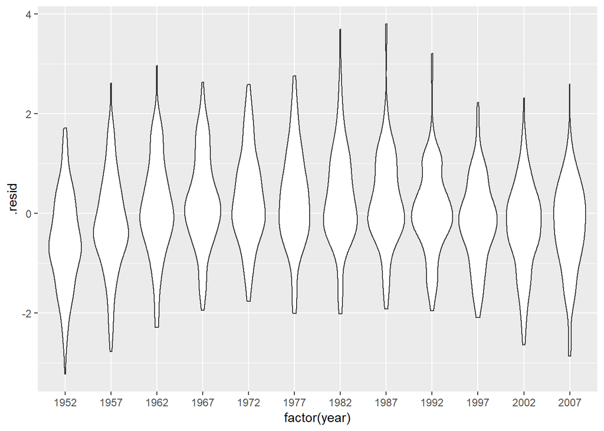

```r
augmentedData %>% ggplot(aes(x = factor(year), y = .resid)) + geom_violin()
```

We further look at the correctness of our model by separating our model by year and we notice that our model still hovers around zero each year but is more spread than previously seen. This could be due to factors we did not account for like education or access to healthcare.

### 4.4 Tree Based Methods

So far we have seen one kind of data model: linear regression. However, this type of model has some shortcomings which can limit prediction ability. For instance, although our linear regression model is mostly correct in predicting fertility rates, the changes in rates over different predictors are not strictly linear relationships. As data scientists, we want to see what other kinds of models are out there so that we can choose the best one for our dataset. This section details some different tree based methods that might yield better results for a model.

#### 4.4.1 Regression Trees

Regression trees, commonly referred to as decision trees, partition the data based on density in a region as opposed to strict, uniform cutoffs across a predictor. One large advantage of this model is that it can be done recursively, leading to a logical, alternate name of “recursive partitioning”.

Let’s start out by creating a regression tree based on the same variables we used in the linear model.

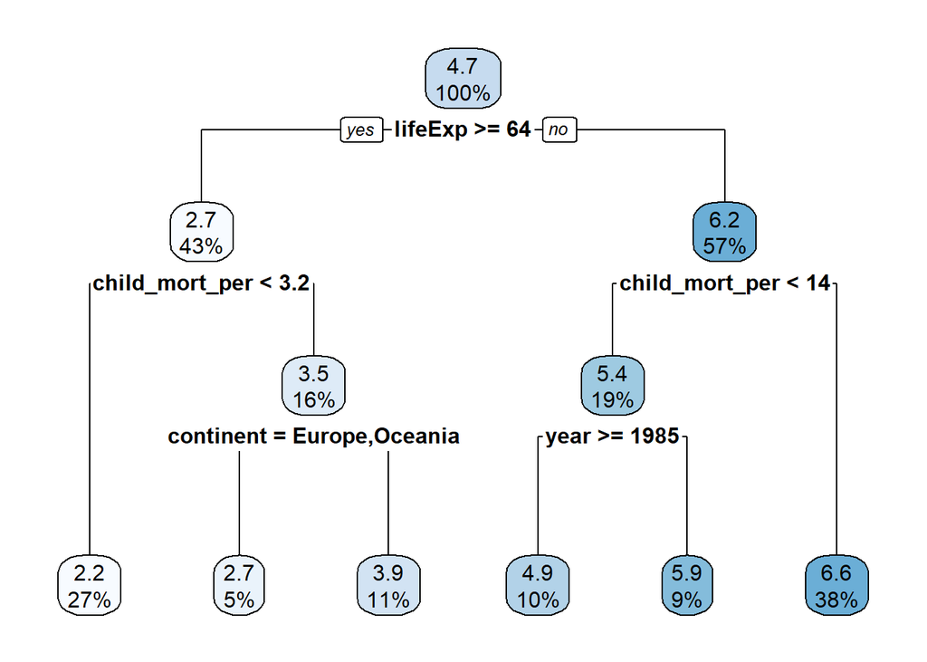

```r
reg_tree <- rpart(birthrate ~ year + continent + income_per_person + lifeExp + child_mort_per,
                  data = birthrate_df)
rpart.plot(reg_tree)
```

The way we interpret this regression tree is that we first choose a country to predict their fertility rate and then we follow the tree, choosing the direction which applies. For instance, let us try to predict the fertility rate for Zimbabwe in 2002. We start at the top of the tree, which asks the life expectancy of Zimbabwe at this time. From our dataset, we can see that the life expectancy is 39.989, which is *not* >= 64, therefore we go right to the “no” subtree. The next condition in the tree is whether the child mortality rate is less than 14 percent. The child mortality rate in Zimbabwe at this time was 9.77%, so we go left to the “yes” subtree. This yes-left, no-right relation holds for the entire tree. Lastly, we check if the year is >= 1985, which is true because the year is 2002, so we go left. We are then given an estimate of 4.9 for the number of children per woman. The actual number at this time was 4.0. So we can see that, although the estimate is not perfect, it gives a good view of where a country approximately lands in terms of fertility rate.

#### 4.4.2 Random Forests

Another tree based method is Random Forests. This method attempts to improve prediction performance by averaging multiple decision trees, such as the one we created in the previous step.

Let’s begin by creating a random forest based on the same attributes that we have been using in the previous models by sampling the data.

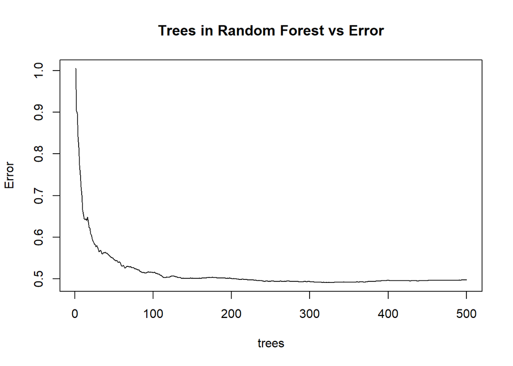

```r
set.seed(1234)
train_indices <- sample(nrow(birthrate_df), nrow(birthrate_df)/2)
train_set <- birthrate_df[train_indices,]
training_rf <- randomForest(birthrate ~ year + continent + income_per_person + lifeExp +
                              child_mort_per,
                            importance=TRUE,
                            mtry=3,
                            data=train_set)
plot(training_rf, main="Trees in Random Forest vs Error")
```

Based on this graph, which plots the error rate depending on the number of trees used, the fewer trees used the worse the error rate is. However, for efficiency we don’t want to use too many trees either. We can see from this graph that the curve starts leveling out at around 150 trees, so that would be the optimal number of trees to create a random forest.

Random forests also allow us to see the levels of importance of the different predictors. As we can see from the table below, year and continent have the highest level of importance, and therefore impact on birthrate.

```r
variable_importance <- importance(training_rf)
knitr::kable(round(variable_importance, digits=2))
```

|  | %IncMSE | IncNodePurity |
| --- | --- | --- |
| year | 44.31 | 116.15 |
| continent | 43.66 | 100.20 |
| income_per_person | 37.11 | 324.26 |
| lifeExp | 37.18 | 1763.28 |
| child_mort_per | 28.16 | 1170.45 |

### 4.5 Model Selection

```r
mean <- mean(birthrate_df$birthrate)
birthrate_df <- birthrate_df %>%
  mutate(high_birth = ifelse(birthrate > mean, "Yes", "No"))
fold_indices <- cvFolds(n=nrow(birthrate_df), K=10)
error_rates <- sapply(1:10, function(fold_index) {
  test_indices <- which(fold_indices$which == fold_index)
  test_set <- birthrate_df[test_indices,]
  train_set <- birthrate_df[-test_indices,]

  # Making the decision tree model
  dec_fit <- rpart(birthrate ~ year + continent + income_per_person + lifeExp + child_mort_per,
                  data = train_set)
  dec_pred <- ifelse(rpart.predict(dec_fit, newdata=test_set) > mean, "Yes", "No")
  dec_error <- mean(test_set$high_birth != dec_pred)

  # Making the random forest model
  rf_fit <- randomForest(birthrate ~ year + continent + income_per_person + lifeExp +
                              child_mort_per,
                            importance=TRUE,
                            mtry=3,
                            data=train_set)
  rf_pred <- ifelse(predict(rf_fit, newdata = test_set) > mean, "Yes", "No")
  rf_error <- mean(test_set$high_birth != rf_pred)

  c(dec_error, rf_error)
  })
rownames(error_rates) <- c("decision tree", "random forest")
error_rates <- as.data.frame(t(error_rates))
error_rates <- error_rates %>%
  mutate(fold=1:n()) %>%
  gather(method,error,-fold)
error_rates %>%
  head() %>%
  knitr::kable("html")
```

| fold | method | error |
| --- | --- | --- |
| 1 | decision tree | 0.0617284 |
| 2 | decision tree | 0.0987654 |
| 3 | decision tree | 0.0555556 |
| 4 | decision tree | 0.0864198 |
| 5 | decision tree | 0.1049383 |
| 6 | decision tree | 0.0864198 |

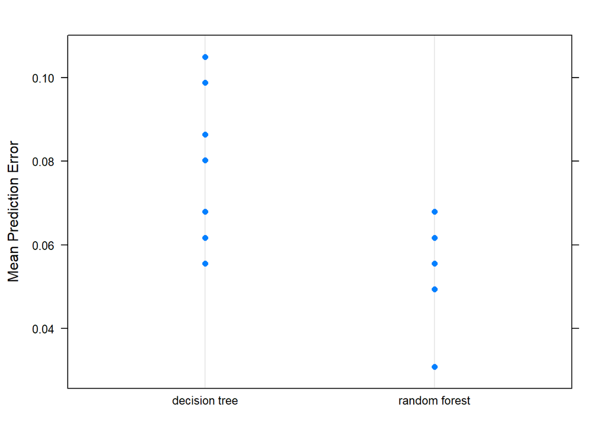

```r
dotplot(error~method, data=error_rates, ylab="Mean Prediction Error")
```

As we can see from the plot above, the decision tree has a slightly higher error rate than the random forest, thus we can conclude that the random forest method would be a more suitable model for this dataset.

For more information on Machine Learning, Data Camp offers a great introduction in R for beginners which includes even more data models! The site can be found here: https://www.datacamp.com/community/tutorials/machine-learning-in-r

## Conclusion

Congratulations! You can now say you are a data scientist. Together we went through the entire data science pipeline to gain valuable insights on birthrates. Learning something new from working with a dataset is a great feeling. You increase your experience in a wide set of skills and in the end you get rewarded by being smarter than you were before the dataset.

Gapminder has provided us with important information regarding child mortality, income per person, birthrates and life expectancy. With all of this data, we have concluded that various factors that are dependent on country play a role in how many children a woman may have in her lifetime.

We encourage you to continue the work we’ve done here and conduct more experiments. Gapminder has a ton of datasets that go well with the ones we have already looked at. Some datasets you might want to look at are “Mean years in school (women of reproductive age 15 to 44)”, “Primary school completion (% of girls)”, and “Contraceptive use (% of women ages 15-49).” In this tutorial we have made assumptions by saying some countries lack the proper sex education and contraceptive methods compared to other countries. You now have the power to prove whether these factors affect birthrates.

If another subject area interests you there will most likely be a data set on it that you can use to make your own analyses on. Some great websites for finding these datasets are:

1. https://www.gapminder.org/data/
2. https://www.kaggle.com/datasets
3. https://registry.opendata.aws/

Good luck and have fun!